# Niche-phenotype mapping in TNBC MIBI data

Anissa El Marrahi

4/7/2022

## Introduction

TMENs are 4 local niches that might explain inter-patient variability in tumor microenvionment cellular composition as a continuum. We previously showed that they help bridging micro (cells neighborhood) and macroscopic tumor architecture (CyTOF experiment on 5x5x5 mm tumors) on breast cancer samples. TMENs were proved to be a a simple framework to study tumor architecture and accurate in the sense that it can retrieve the original tumor cell composition.

However, we still lack a quantitative framework to analyze the TME in a higher level of abstraction: cell phenotypes <–> cell markers expression. We know that for example, there is high variability in immune response of TILs (pro/anti-inflammation) within the tumor microenvironment. It is relevant to study how the environment impacts the differential expression of different markers at the single-cell level. However, a spatial coarse-grained approach is hard to tackle. The need for a simplified framework to study this question grows as the level of accuracy in the exploration of the tumor microenvironment increases. Therefore, it is legitimate to assess the relevance of TMENs as a framework to explore the phenotypical diversity of cells within the TME.

## Loading libraries and data

```r
gc()
```

```
##          used (Mb) gc trigger (Mb) max used (Mb)
## Ncells 524122 28.0    1164614 62.2   665754 35.6
## Vcells 975574  7.5    8388608 64.0  1819512 13.9
```

```r
rm(list=ls())
library(tidyverse)
```

```r
library(plotly)
library(reticulate)
library(ade4)
library(reticulate)
library(htmltools)
library(factoextra)
library('Ternary')
library(pheatmap)
source("./functions_phenotypes_tmens.r")
dirName <- dirname(rstudioapi::getSourceEditorContext()$path )
setwd(dirName)#setwd(dir = "/scratch/anissa.el/ImmuneStates/phenot_tmens")
```

### Constant variables

```r
CELLTYPES <- c('CD8-T', 'Other immune', 'DC / Mono', 'CD3-T', 'B', 'NK', 'Keratin-positive tumor', 'Tumor','CD4-T', 'Mesenchymal-like', 'Macrophages', 'Endothelial', 'Tregs', 'DC', 'Mono / Neu','Neutrophils')## Removed Unidentified cells
NBCELLTYPES = length(CELLTYPES)
MARKERS <- c("dsDNA","Vimentin","SMA","B7H3","FoxP3","Lag3","CD4","CD16","CD56","OX40","PD1","CD31","PD.L1","EGFR","Ki67","CD209","CD11c","CD138","CD163","CD68","CSF.1R","CD8","CD3","IDO","Keratin17","CD63","CD45RO","CD20","p53","Beta.catenin","HLA.DR","CD11b","CD45","H3K9ac","Pan.Keratin","H3K27me3","phospho.S6","MPO","Keratin6","HLA_Class_1")
```

### Sites and TMENs data

```r
archsToTMENs <- read.csv("../data_BB/archetypes_building_blocks_17cells_space_gaussian.csv")
# ARCH1: TLS
# ARCH2: INFLAMMATORY NICHE
# ARCH3: CANCER NICHE
# ARCH4: FIBROTIC/NECROTIC NICHE
cell_markers <- read.csv('/scratch/anissa.el/ImmuneStates/cellData.csv',header = TRUE, sep =',')

#colnames(cell_markers)
cell_markers <- cell_markers %>% relocate(Background, .after = cellLabelInImage)
cell_markers <- dplyr::select(cell_markers,-(cellSize:Fe))
#SampleID,cellLabelInImage,cell_markers,Pan.Keratin,Keratin6,Keratin17,p53,Beta.catenin,EGFR,
#                        dsDNA,H3K9ac,H3K27me3,phospho.S6,Ki67,
#                        CD45,CD3,CD8,CD4,FoxP3,CD20,CD45RO,CD56,CD16,CD138,CD11b,CD11c,CD68,CD63,MPO,HLA.DR,HLA_Class_1,CD209,
#                        Lag3,PD1,PD.L1,IDO,
#                        Vimentin,SMA,CD31,
#                        B7H3,OX40,CD163,CSF.1R,tumorYN,tumorCluster,Group,immuneGroup

cell_markers <- dplyr::select(cell_markers,-c( immuneCluster, Ta, Au))%>%
  mutate(immuneGroup = recode(immuneGroup,`0`= 'None',`1`='Tregs', `2`='CD4-T',
                              `3`='CD8-T', `4`='CD3-T', `5`='NK',
                    `6`='B', `7`='Neutrophils', `8`='Macrophages', `9`='DC',
                    `10`='DC / Mono', `11`='Mono / Neu', `12`='Other immune')) %>%
  mutate(Group = recode(Group,`1`='Unidentified', `2`='Immune',
                        `3`='Endothelial', `4`='Mesenchymal-like',
                        `5` = 'Tumor',
                        `6` = 'Keratin-positive tumor'))

cell_markers <- cell_markers%>%
  mutate(cell_type = ifelse(Group == 'Immune', cell_type<- immuneGroup,cell_type <- Group))%>%
  dplyr::select(-(tumorYN:immuneGroup))%>%filter(cell_type!="Unidentified")

cell_markers <- cell_markers%>%
  dplyr::rename(patient_id = SampleID)%>%
  dplyr::rename(cell_id = cellLabelInImage)%>%
  mutate(H3K9ac_H3K27me3 = H3K9ac/H3K27me3)
#colnames(cell_markers)

#### Select functional markers

stateMarkers <- read.csv("./data/proteins_by_frame.csv")
FuncMarkers <- stateMarkers%>%filter(Purpose =="Functional")%>%pull(Biomarker)

FuncMarkers <- append(str_replace_all(FuncMarkers,c("HLA-DR"="HLA.DR","PD-L1" = "PD.L1","phospho-S6" = "phospho.S6","Beta catenin" = "Beta.catenin")),"H3K9ac_H3K27me3")
```

#### Hierarchical clustering of cell types by functional markers

```r
library(cluster)


CellsFunctMarkers.df <- cell_markers[which(cell_markers$cell_type %in% c("DC")),append(append(FuncMarkers,"cell_type"),"cell_id")]#%>%mutate(id = paste0(cell_type,"_",cell_id))%>%column_to_rownames(var="id")#%>%group_by(cell_type) c("DC", "Keratin-positive tumor", "NK", "Neutrophils", "Tregs")
rownames(CellsFunctMarkers.df) <- make.names(paste0(CellsFunctMarkers.df$cell_type,"_",CellsFunctMarkers.df$cell_id),unique=TRUE)
#cells.markers <- group_split(CellsFunctMarkers.df )

ZscoreScale <- function(M, cutOff=3) {
  M0 = apply(M, 2, function(x) {(x-mean(x)) / sd(x)}) %>% t
  M0[M0>cutOff] = cutOff
  M0[M0<(-cutOff)] = -cutOff
  return(M0)
}
#list_heatmap <- lapply(cells.markers, FUN = function(x) pheatmap(as.matrix(x%>%dplyr::select(-(cell_type)))))
cm.mat <- CellsFunctMarkers.df%>%dplyr::select(-c(cell_type,cell_id))%>%ZscoreScale()%>%t()
CM.dist <- dist(cm.mat,method="euclidian")
clust.DC <- hclust(CM.dist,method = "ward.D")
sub_grp <-  data.frame(cell_id=names(cutree(clust.DC, k = 10)),cluster=cutree(clust.DC, k = 10),row.names=NULL)
#cm.mat[,'cluster'] <- sub_grp

clustMarkers.zscore <- cm.mat %>%as_tibble(rownames=NA)%>%rownames_to_column(var="cell_id")%>%
  left_join(.,sub_grp, by="cell_id")%>%
  pivot_longer(cols = FuncMarkers, names_to="marker",values_to = "value")%>%
  group_by(cluster,marker)%>%
  mutate(meanMClust = mean(value))%>%
  distinct(cluster,marker,meanMClust)%>%
  pivot_wider( names_from='marker',values_from = "meanMClust")%>%column_to_rownames(var="cluster")
```

```
## Note: Using an external vector in selections is ambiguous.
## ℹ Use `all_of(FuncMarkers)` instead of `FuncMarkers` to silence this message.
## ℹ See <https://tidyselect.r-lib.org/reference/faq-external-vector.html>.
```

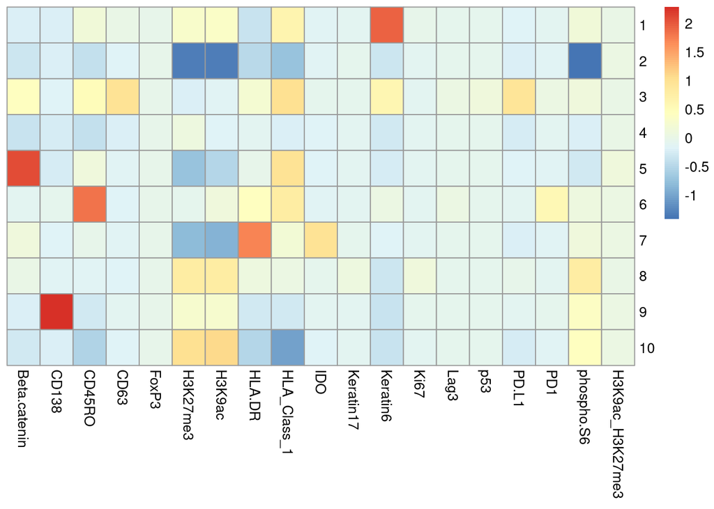

```r
pheatmap(as.matrix(clustMarkers.zscore),cluster_cols = FALSE,cluster_rows = FALSE)
```

```r
#pheatmap(as.matrix(CellsFunctMarkers.df), cluster_cols = FALSE)
#fviz_cluster(list(data = CellsFunctMarkers.df%>%dplyr::select(-(cell_type)), cluster = sub_grp))
##pheatmap(as.matrix(CellsFunctMarkers.df%>%dplyr::select(-c(cell_type,cell_id))%>%t%>%scale()),cellheight= 15,show_colnames = FALSE)
#plot(clust.DC)

## Hierarchical clustering on cells from the same type, ward's method (variance minimization, scaled with cut-off value of markers intensity =3)
hclust_cellTypes <- function(){

  CellsFunctMarkers.df <- cell_markers[which(cell_markers$cell_type %in% c("DC", "NK", "Neutrophils", "Tregs","Macrophages")),append(append(all_of(FuncMarkers),"cell_type"),"cell_id")]# "Keratin-positive tumor"

  rownames(CellsFunctMarkers.df) <- make.names(paste0(CellsFunctMarkers.df$cell_type,"_",CellsFunctMarkers.df$cell_id),unique=TRUE)
  #print(rownames(CellsFunctMarkers.df))
  cells.markers <- group_split(CellsFunctMarkers.df%>%group_by(cell_type))
  #print(cells.markers)

  list_heatmaps <-lapply(cells.markers, FUN = function(x) {
    print(unique(x$cell_type))
    ct <- unique(x$cell_type)

    cm.mat <- x%>%dplyr::select(-c(cell_type,cell_id))%>%ZscoreScale()%>%t()
    print(dim(cm.mat))
    CM.dist <- dist(cm.mat,method="euclidian")
    Cells.hclust <- hclust(CM.dist,method = "ward.D")
    #print(table(cutree(Cells.hclust, k = 10)))
    sub_grp <-  data.frame(cell_id=seq(1,nrow(x),1),cluster=cutree(Cells.hclust, k = 10),row.names=NULL)
    #cm.mat[,'cluster'] <- sub_grp

    clustMarkers.zscore <- cm.mat %>%as_tibble()%>%mutate(cell_id=seq(1,nrow(x),1))%>%#as_tibble(rownames=NA)%>%rownames_to_column(var="cell_id")%>%
      left_join(.,sub_grp, by="cell_id")%>%
      pivot_longer(cols = FuncMarkers, names_to="marker",values_to = "value")%>%
      group_by(cluster,marker)%>%
      mutate(meanMClust = mean(value))%>%
      distinct(cluster,marker,meanMClust)%>%
      arrange(marker)%>%
      pivot_wider( names_from='marker',values_from = "meanMClust")%>%column_to_rownames(var="cluster")
    pdf(paste0("./figs/",ct,"cells_clusters.pdf"),width=6.5,height=5)
    pheatmap(as.matrix(clustMarkers.zscore%>%t()),cluster_cols = FALSE,cluster_rows = FALSE,main=ct,cell_width=1.5,cell_height = 2)
    dev.off()
  })
  return(list_heatmaps)
}

hclust_cellTypes()
```

```
## [1] "DC"
## [1] 1275   19
```

```
## [1] "Macrophages"
## [1] 20687    19
```

```
## [1] "Neutrophils"
## [1] 3020   19
```

```
## [1] "NK"
## [1] 674  19
```

```
## [1] "Tregs"
## [1] 1341   19
```

```r
## TODO
### Remove markers that have a weak association to the TMENs
### OR keep all markers in correlation matrix for each cell to make it easy to compare
```

```r
#use read_csv and write_rds
#tmens_cells <- read.csv("../data_BB/archetypes_sites_centered_cells_gaussian.csv")%>%filter(cell_type_site!="Unidentified")#remove Unidentified cells from analysis  archetypes_sites_centered_cells_gaussian.csv
tmens_cells2 <- read.csv("../data_BB/archetypes_sites_centered_cells_gaussian2.csv")%>%filter(cell_type_site!="Unidentified")
#rowSums(tmens_cells[,c("archetype1","archetype2","archetype3","archetype4")])
```

## Selection of markers/cell types of interest

```r
markersPerCell <- cell_markers%>%pivot_longer(cols = c("dsDNA","Background","Vimentin","SMA","B7H3","FoxP3","Lag3","CD4","CD16","CD56","OX40","PD1","CD31","PD.L1","EGFR","Ki67","CD209","CD11c","CD138","CD163","CD68","CSF.1R","CD8","CD3","IDO","Keratin17","CD63","CD45RO","CD20","p53","Beta.catenin","HLA.DR","CD11b","CD45","H3K9ac","Pan.Keratin","H3K27me3","phospho.S6","MPO","Keratin6","HLA_Class_1","H3K9ac_H3K27me3"),names_to = "marker", values_to= "value")
markersPerCell.sd <- markersPerCell%>% group_by(cell_type, marker)%>%summarise(sd = sd(value))
```

```r
#MarkersCells.var <- left_join(selectedMarkers, markersPerCell,by= c("cell_type","marker"))

# ggplot(data = markersPerCell.sd ,aes(x=cell_type,y = sd,group = marker))+
#   geom_point()+#scale_y_log10()+geom_boxplot()+
#   geom_hline(yintercept=2, linetype="dashed", color = "red")+
#   theme(axis.text.x = element_text(angle = 90, hjust = 0.2, vjust = 0.2))+
#   labs(x = "")

#selectedMarkers <- markersPerCell.sd%>%filter(sd >=2)#%>%ungroup()%>%dplyr::select(marker)%>%unique()
#saveRDS(selectedMarkers,"./selected_markers_cells.rds")
```

```r
sitesCellsCM <- left_join(markersPerCell%>%rename(site_id=cell_id),tmens_cells2, by=c("patient_id","site_id"))%>%filter(!is.na(cell_type_site))

ggplot(sitesCellsCM%>%filter(marker=='Keratin6'),aes(x=TOT_cell_dens,y=value))+
  geom_point(alpha=.02)+
  geom_density_2d()
  #stat_cor(method="spearman",cor.coef.name="rho",label.x=0.015,label.y=6)

ggplot(sitesCellsCM%>%filter(marker=='Keratin6'),aes(y=value, group=cell_type,fill=cell_type))+
  geom_boxplot()

ggplot(sitesCellsCM%>%filter(marker=='Beta.catenin'),aes(x=TOT_cell_dens,y=value))+
  geom_point(alpha=.02)+
  geom_density_2d()
```

## TMENS as a new way to describe single-cell local environment

```r
#MarkersCells.var <- left_join(selectedMarkers, markersPerCell,by= c("cell_type","marker"))
### Markers expr for all cell types from all sites
if (file.exists("./outputs/MarkersCellsTMENs.rds")){
  MarkersCellsTMENS <- readRDS("./outputs/MarkersCellsTMENs.rds")
}else{
  MarkersCellsTMENS <- left_join(markersPerCell%>%rename(site_id=cell_id),tmens_cells2, by=c("patient_id","site_id"))%>%filter(!(is.na(arch1)| is.na(arch2)| is.na(arch3) | is.na(arch4)))%>%
  mutate(a1a2 = arch1*arch2)%>%
  mutate(a1a3 = arch1*arch3)%>%
  mutate(a1a4 = arch1*arch4)%>%
  mutate(a2a3 = arch2*arch3)%>%
  mutate(a2a4 = arch2*arch4)%>%
  mutate(a3a4 = arch3*arch4)%>%
  mutate(a1a2a3 = arch1*arch2*arch3)%>%
  mutate(a1a2a4 = arch1*arch2*arch4)%>%
  mutate(a1a3a4 = arch1*arch3*arch4)%>%
  mutate(a2a3a4 = arch2*arch3*arch4)%>%
  mutate(a1a2a3a4 = arch1*arch2*arch3*arch4)


  saveRDS(MarkersCellsTMENS,"./outputs/MarkersCellsTMENs.rds")
}

MarkersCellsTMENS2 <- left_join(markersPerCell%>%rename(site_id=cell_id),tmens_cells2, by=c("patient_id","site_id"))%>%filter(!(is.na(arch1)| is.na(arch2)| is.na(arch3) | is.na(arch4)))%>%
  mutate(a1a2 = arch1*arch2)%>%
  mutate(a1a3 = arch1*arch3)%>%
  mutate(a1a4 = arch1*arch4)%>%
  mutate(a2a3 = arch2*arch3)%>%
  mutate(a2a4 = arch2*arch4)%>%
  mutate(a3a4 = arch3*arch4)%>%
  mutate(a1a2a3 = arch1*arch2*arch3)%>%
  mutate(a1a2a4 = arch1*arch2*arch4)%>%
  mutate(a1a3a4 = arch1*arch3*arch4)%>%
  mutate(a2a3a4 = arch2*arch3*arch4)%>%
  mutate(a1a2a3a4 = arch1*arch2*arch3*arch4)
#### Only highly variable markers expr from selected cell types across patients/sites

#MarkersCellsTMENS.selected <- left_join(selectedMarkers,MarkersCellsTMENS,by=c("cell_type","marker"))#left_join(MarkersCells.var%>%rename(site_id=cell_id),tmens_cells, by=c("patient_id","site_id"))
#saveRDS(MarkersCellsTMENS,"./markers_cells_tmens.rds")
```

Plot the proportions of TMENs and show the intensity of the marker for cell type

```r
library(ggpubr)

MarkersCellsTMENS1 <- MarkersCellsTMENS%>%dplyr::rename(TLS=arch1)%>%
  dplyr::rename(inflamm = arch2)%>%dplyr::rename(fibrotic=arch4)%>%
  dplyr::rename(cancer=arch3)

MarkersCellsTMENS.reduc <- MarkersCellsTMENS2%>%dplyr::rename(TLS=arch1)%>%
  dplyr::rename(inflamm = arch2)%>%dplyr::rename(fibrotic=arch4)%>%
  dplyr::rename(cancer=arch3)


ggplot(data=MarkersCellsTMENS.reduc%>%filter(cell_type=="Keratin-positive tumor"& marker=="HLA_Class_1"),aes(x=inflamm*cancer,y=value))+
  geom_point(alpha=.1)+
  #geom_density_2d()+
  #scale_y_continuous(trans="log")+ #scale_x_continuous(trans="log")+
  stat_cor(method="spearman",cor.coef.name="rho",label.x=0.1)+
  stat_cor(method="pearson",cor.coef.name="R",label.y=4.0,label.x=0.1)+
  ggtitle("Ker+ tumor w/MHCI VS inflamm x cancer")

ggplot(data=MarkersCellsTMENS.reduc%>%filter(cell_type=="Tregs"& marker=="phospho.S6"),aes(x=inflamm*cancer,y=value))+
  geom_point(alpha=.1)+
  #geom_density_2d()+
  #scale_y_continuous(trans="log")+ #scale_x_continuous(trans="log")+
  stat_cor(method="spearman",cor.coef.name="rho",label.x=0.1)+
  stat_cor(method="pearson",cor.coef.name="R",label.y=4.0,label.x=0.1)+
  ggtitle("Tregs w/Phospho-S6 VS inflamm x cancer")

ggplot(data=MarkersCellsTMENS.reduc%>%filter(cell_type=="Neutrophils"& marker=="HLA.DR"),aes(x=inflamm,y=value))+
  geom_point(alpha=.1)+
  #geom_density_2d()+
  #scale_y_continuous(trans="log")+ #scale_x_continuous(trans="log")+
  stat_cor(method="spearman",cor.coef.name="rho",label.x=0.1)+
  stat_cor(method="pearson",cor.coef.name="R",label.y=4.0,label.x=0.1)+
  ggtitle("HLA-DR-expr Neutrophils VS inflamm")

ggplot(data=MarkersCellsTMENS.reduc%>%filter(cell_type=="Neutrophils"& marker=="PD.L1"),aes(x=inflamm*cancer,y=value))+
  geom_point(alpha=.1)+
  #geom_density_2d()+
  #scale_y_continuous(trans="log")+ #scale_x_continuous(trans="log")+
  stat_cor(method="spearman",cor.coef.name="rho",label.x=0.1)+
  stat_cor(method="pearson",cor.coef.name="R",label.y=4.0,label.x=0.1)+
  ggtitle("PD-L1-expr Neutrophils VS inflamm x cancer")

ggplot(data=MarkersCellsTMENS.reduc%>%filter(cell_type=="Neutrophils"& marker=="IDO"),aes(x=inflamm*cancer,y=value))+
  geom_point(alpha=.1)+
  #geom_density_2d()+
  #scale_y_continuous(trans="log")+ #scale_x_continuous(trans="log")+
  stat_cor(method="spearman",cor.coef.name="rho",label.x=0.1)+
  stat_cor(method="pearson",cor.coef.name="R",label.y=5.0,label.x=0.1)+
  ggtitle("IDO-expr Neutrophils VS inflamm x cancer")

ggplot(data=MarkersCellsTMENS.reduc%>%filter(cell_type=="NK"& marker=="CD138"),aes(x=fibrotic,y=value))+
  geom_point(alpha=.1)+
  #geom_density_2d()+
  #scale_y_continuous(trans="log")+ #scale_x_continuous(trans="log")+
  stat_cor(method="spearman",cor.coef.name="rho",label.x=0.1)+
  stat_cor(method="pearson",cor.coef.name="R",label.y=5.0,label.x=0.1)+
  ggtitle("CD138-expr NK VS fibrotic")

#### Does not follow a normal dist
## Many extreme outliers
# spearman correlations instead
NeutroPDL1 <- MarkersCellsTMENS.reduc%>%filter(cell_type=="Neutrophils"& marker=="PD.L1")%>%pull(value)
shapiro.test(NeutroPDL1)
qqnorm(NeutroPDL1, pch = 1, frame = FALSE)
#qqline(NeutroPDL1, col = "steelblue", lwd = 2)

# ggplot(data=MarkersCellsTMENS1%>%filter(cell_type=="Neutrophils"& marker=="PD.L1"),aes(y=value))+
#   geom_boxplot()
```

## Marker-space association

To do so, we’ll fit a dirichlet (modified) distribution onto the intensity of a marker of a cell type.

```r
NB_TMENs <- 4
## PARAMETERS : k ct and gamma vector
## pars = (gamma_1,...,gamma_n,k)
## Minimizing function to fit dirichlet distribution
## x_cm(alpha): intensity of marker m in cell type c
## x_cap: fitted intensity
## alpha: vector of position in TMENs simplex

func <-function(data, pars){
  # f1<-1
  # for (i in range(NB_TMENs)){
  #   f1 <-with(x_cm, f1 * (x_cm[i]^pars[i])) #f1 * (x_cm[i]^pars[i])#(alpha[i]^pars[i])
  # }
  # B <- with(x_cm,beta(list(arch1,arch2,arch3,arch4)))#(as.vector(x_cm[,c("arch1","arch2","arch3","arch4")]))#(alpha)
  # x_cap <- (1/B)*pars[NB_TMENs+1]*with(x_cm, prod(c(arch1,arch2,arch3,arch4)^pars[1:NB_TMENs]))#f1
  #beta(arch1,arch2,arch3,arch4))*pars[NB_TMENs+1]  (1/(prod(sapply(pars[1:NB_TMENs],function(x) gamma(x)))/gamma(sum(pars[1:NB_TMENs]))))*
  with(data, sum((value - (pars[NB_TMENs+1]* apply(cbind(arch1,arch2,arch3,arch4),1,function (x) prod(diag(outer(x,pars[1:NB_TMENs],FUN="^"))))))^2))#with(data, sum((value - (pars[NB_TMENs+1]* prod(diag(outer(c(arch1,arch2,arch3,arch4),pars[1:NB_TMENs],FUN="^")))))^2)) #(as.vector(x_cm[,"value"]) - x_cap)^2
}

#apply(data[,c(arch1,arch2,arch3,arch4)],1,function (x) prod(diag(outer(x,c(0.5,1,-2,5),FUN="^"))))
```

```r
init <- c(0.1,0.1,0.1,0.1,1)
eps <- 10^-4 ## small variation we add to alpha values in case they are null to avoid pbs in the fitting
x_cm <- get_tmens_coord_marker("B","CD20",eps)
#x_cm2 <- get_tmens_coord_marker("CD4-T","PD1")
estim_params <- optim(par = init, fn = func,data = x_cm,method = "L-BFGS-B",lower = c(-100,-100,-100,-100,0),upper = c(rep(100,NB_TMENs),Inf),
                       control = list(trace = 3,
                              maxit = 1000))
#method = "L-BFGS-B",lower = rep(0,5),upper = c(rep(100,NB_TMENs),Inf),

#params2 <- optim(par= init, fn= func,data = x_cm2,method = "L-BFGS-B",lower = c(-100,-100,-100,-100,0),upper=c(100,100,100,100,Inf))
```

```r
params_PD1_CD8T <-read.csv("./GradDesc_CM_tmens/fittedParamsGammaKm_PD1_CD8T.csv")
p1 <- params_PD1_CD8T%>%pull(x)
params_CD20_B<- read.csv("./GradDesc_CM_tmens/fittedParamsGammaKm_CD20_B.csv")
p2 <- params_CD20_B%>%pull(x)
x_cm <- get_tmens_coord_marker("B","CD20",10^-4)
f1 <- function(pars,x_cm){
  res <-(pars[NB_TMENs+1]* apply(x_cm[c("arch1","arch2","arch3","arch4")],1,function (x) prod(diag(outer(x,pars[1:NB_TMENs],FUN="^")))))
  return(res)
}
x_cm_fit <- x_cm %>%mutate(fitted_val=f1(p1,x_cm))
#plot(x_cm$arch1,x_cm$value)
ggplot(data = x_cm_fit)+
  geom_point(aes(x=arch1,y=value))+
  geom_line(aes(x=arch1,fitted_val,color="red"))
```

```r
#m2 <- c("Pan.Keratin","Keratin6","Keratin17","p53","EGFR","Beta.catenin","dsDNA","H3K9ac","H3K27me3","phospho.S6","Ki67","CD45","CD3","CD8","CD4","FoxP3","CD20","CD45RO","CD56","CD16","CD138","CD11b","CD11c","CD68","CD63","MPO","HLA.DR","HLA_Class_1","CD209","Lag3","PD1","PD.L1","IDO","Vimentin","SMA","CD31")

init <- c(0.01,0.01,0.01,0.01,1)
ParamsDirichlet <- matrix(nrow=length(MARKERS)*length(CELLTYPES),ncol = NB_TMENs+3)
colnames(ParamsDirichlet) <- c("cell_type","marker","gamma1","gamma2","gamma3","gamma4","km")
idx <- 1
for (i in 1:length(CELLTYPES)){
  for(j in 1:length(MARKERS)){
    #print(CELLTYPES[i])
    ParamsDirichlet[idx,c("cell_type","marker")] <- c(CELLTYPES[i],MARKERS[j])
    x_cm <- get_tmens_coord_marker(CELLTYPES[i],MARKERS[j])
    NCELLS <- nrow(x_cm) ## DIVIDE SS by nb of cells ?? If grad desc is too long
    estim_params <- optim(par= init, fn=func,data = x_cm,method = "L-BFGS-B",lower = c(-100,-100,-100,-100,0),upper=c(100,100,100,100,Inf))
    ParamsDirichlet[idx,c("gamma1","gamma2","gamma3","gamma4","km")]<- estim_params$par
    idx <- idx+1
  }
}
```

## Linear relationship between markers and TMENS ?

### Assessing phenotypes-TMENs with spearman correlations

```r
#cMf <- correlations_tmens_CM(MarkersCellsTMENs=MarkersCellsTMENS,cellTypes=CELLTYPES, markers=FuncMarkers)
cMf2<- correlations_tmens_CM(MarkersCellsTMENs=MarkersCellsTMENS2,cellTypes=CELLTYPES, markers=FuncMarkers)
```

```
## Step 1... determine cutoff point
## Step 2... estimate parameters of null distribution and eta0
## Step 3... compute p-values and estimate empirical PDF/CDF
## Step 4... compute q-values and local fdr
## Step 5... prepare for plotting
```

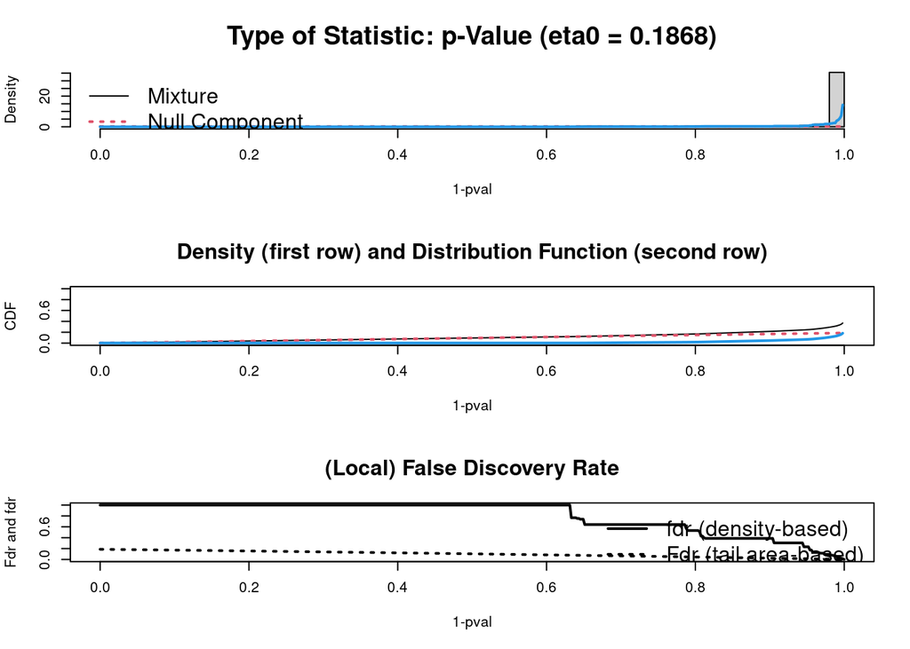

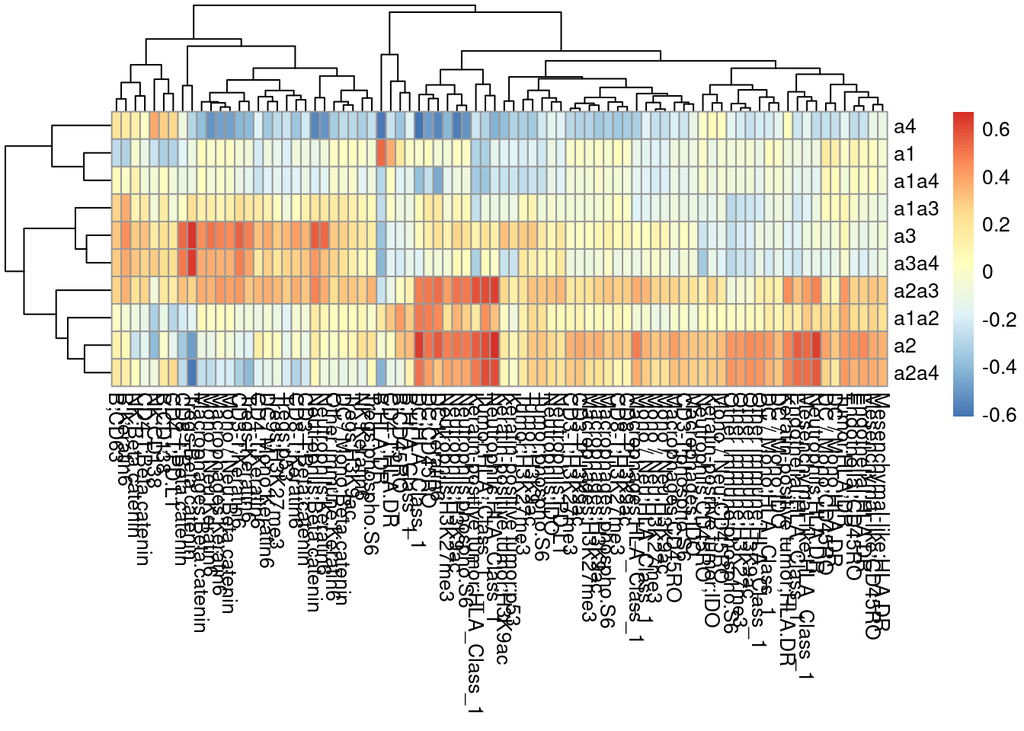

```r
write_csv(cMf2%>%as_tibble(rownames=NA)%>%rownames_to_column(var="cell_marker"), "./CM_corr_tmensREDUCED_thresh0.3.csv")
# if(file.exists()){
#
# }else{
#   cMf <- correlations_tmens_CM(MarkersCellsTMENs=MarkersCellsTMENS,cellTypes=CELLTYPES, markers=FuncMarkers)
# }
# rm(cMf)
#saveRDS(cMf,"./corMatrixCM_fdr.rds")
#cMf <- readRDS("./corMatrixCM_fdr.rds")
figWidth <- nrow(cMf2) * 30/267
#pheatmap(cMf%>%t)

pheatmap(cMf2%>%t)
```

```r
#pdf("./figs/cMf2.pdf", height=8, width=ifelse(figWidth<6, 6, figWidth+2)); pheatmap(cMf2%>%t); dev.off()
######## VISUALIZATION ################

# figWidth <- nrow(cMf) * 30/267
# pdf("cMf_original.pdf", height=10, width=21); pheatmap(cMf %>% t,cluster_rows=FALSE,cluster_cols=FALSE); dev.off()
#

#pdf("./figs/cMf_reduced.pdf", height=8, width=ifelse(figWidth<6, 6, figWidth+2)); pheatmap(cMf %>% t); dev.off()

############ ORDER BY MARKERS: phenotype --> environment

#pheatmap(cMf)
# rownames(cMf)<- unname(unlist(sapply(rownames(cMf),function(x){paste0(strsplit(x,";")[[1]][2],";",strsplit(x,";")[[1]][1])})))#sub('(\\w|\\.|\\_|\\ / |+);(\\w|.|_| / |+)', '\\2;\\1', rownames(cMf))#sub('([^;]);([^;])', '\\2;\\1^', rownames(cMf))
#
 # cMf_ordered <- cMf%>%as_tibble(rownames=NA)%>%rownames_to_column(var="names")%>%separate(col="names",into=c("marker","cell_type"),sep=";")%>%group_by(marker)%>%arrange(marker)%>%mutate(names=paste0(marker,";",cell_type))%>%column_to_rownames(var="names")%>%dplyr::select(-c(cell_type,marker))
 # pdf("./figs/cM_orderMarkers.pdf",height=10,width=15)
 # pheatmap(as.matrix(cMf_ordered )%>%t,cluster_rows = FALSE,cluster_cols = FALSE)
 # dev.off()
```

```r
#library(gt)
#library(mmtable2)
library(grid)
library(gridExtra)

tabTMENs <- as_tibble(cMf,rownames=NA)%>%
  rownames_to_column(var="names")%>%
  separate(names,into=c("cell_type","marker"),sep=";")%>%
  mutate(marker=paste0(marker,"+"))%>%
  pivot_longer(cols=c('a1','a2','a3',"a4","a1a2","a1a3","a1a4","a2a3","a2a4","a3a4"),names_to = "region",values_to="corr_val")%>%
  mutate(region = set_tmens_names(region))%>%
  group_by(region)%>%
  filter(corr_val ==  max(corr_val))%>% #(corr_val%in% head(sort(corr_val,3)))
  dplyr::select(-(corr_val))%>%#mutate(sign  = "+")
  relocate(region)%>%arrange(region)

## Display table and save pdf

g <- tableGrob(tabTMENs,rows=NULL)
grid.newpage()
grid.draw(g)
#ggsave("./figs/tab_tmens1.pdf",g,width=4,height=3)
```

```r
library(grid)
library(gridExtra)

tabTMENs2 <- as_tibble(cMf,rownames=NA)%>%
  rownames_to_column(var="names")%>%
  separate(names,into=c("cell_type","marker"),sep=";")%>%
  mutate(marker=paste0(marker,"+"))%>%
  pivot_longer(cols=c('a1','a2','a3',"a4","a1a2","a1a3","a1a4","a2a3","a2a4","a3a4"),names_to = "region",values_to="corr_val")%>%
  group_by(region)%>%
  mutate(region = set_tmens_names(region))%>%
  filter(corr_val%in% head(sort(corr_val,decreasing=TRUE),3)& corr_val >=0.3)%>% #
  mutate(cell_phenotype = paste(marker,cell_type,collapse="\n"),.keep="unused")%>%
  dplyr::select(-(corr_val))%>%#mutate(sign  = "+")
  distinct(region, .keep_all = TRUE)%>%arrange(region)
tabTMENs2


### Display and save table in pdf
th1 <- ttheme_minimal(colhead=list(bg_params=list(col="black",fill = "white")),
                      core=list(bg_params = list(fill = 'white', col="black")))

g1 <- tableGrob(tabTMENs2,rows=NULL,theme = th1)
                #gpar.corefill = gpar(fill = "white", col = "grey95"))
grid.newpage()
grid.draw(g1)
#ggsave("./figs/tab_tmens2.pdf",g1,width=6,height=8)

rm(g1)
```

```r
library(grid)
library(gridExtra)
#install.packages("fontLiberation")
library(fontLiberation)

archetypesSitesKeren <- readRDS("/scratch/anissa.el/ImmuneStates/data_BB/archetypesSitesKeren.rds")
cellAbSites <- read_csv("/scratch/anissa.el/ImmuneStates/data_BB/abundance_matrix_gaussian.csv")
archs.CT <- get_CT_enriched_all_archs(archetypesSitesKeren,cellAbSites,thresh = 0.99)%>%group_by(niche)%>%filter(!(cell_type %in% c("DC / Mono", "CD3-T", "Mono / Neu", "Other immune")))%>%mutate(cell_type = paste(unique(cell_type),collapse="\n"))%>%distinct(niche,cell_type)
#names(archs.CT) <- set_tmens_names(names(archs.CT))


tabTMENs2 <- as_tibble(cMf2,rownames=NA)%>%
  rownames_to_column(var="names")%>%
  separate(names,into=c("cell_type","marker"),sep=";")%>%
  mutate(marker=paste0(marker,"+"))%>%
  pivot_longer(cols=c('a1','a2','a3',"a4","a1a2","a1a3","a1a4","a2a3","a2a4","a3a4"),names_to = "niche",values_to="corr_val")#%>%
  #mutate(region =)%>%#(region = set_tmens_names(region))%>%
tabTMENs2$niche <- str_replace_all(pull(tabTMENs2,niche), c("a2a3"="inflammatoryxcancer",
                                                           "a1a3" = "TLSxcancer",
                                                           "a1a2"= "TLSxinflammatory",
                                                           "a1a4" = "TLSxfibrotic",
                                                           "a2a4" ="inflammatoryxfibrotic",
                                                           "a3a4" = "cancerxfibrotic"))
tabTMENs2$niche <- str_replace_all(pull(tabTMENs2,niche),c("a1" = "TLS","a2" = "inflammatory","a3" = "cancer","a4" = "fibrotic"))

tabTMENs2 <- tabTMENs2%>% filter(corr_val >=0.3)#%>% #### Select correlations that are >0.35
#  full_join(.,archs.CT,by="region")%>%group_by(region,cell_type.x,marker)%>%mutate(cell_type.y = paste(unique(cell_type.y),collapse="\n"))%>%ungroup()#left_join(., archs.CT,by=c("region","cell_type")) #### include cell_types that are representative of a given region

######### Compare correlations from core VS from interfaces
  # group by cell type, marker
  #find rows with a common detemrinant: a TMEN
    # split region into two (for 2- interfaces)
    # find intersect between two subregions ==> common TMEN
    # OR find the TMEN that has the highest occurence in a subregion (core and interfacees) across same CM VStmens associations
    # OR the same but for the second subregion
    # IF there is an association between CM and one region ==> common region is the latter
  # group again by cell type, marker, and by this common region
  # select the maximum
  #Get the correlations among core/interfaces for a given cell _type/marker that are the highest
  # Ex: rho (Beta-cat+ Tregs, cancer) < rho( Beta-cat+ Tregs, cancer x fibrotic)
  # ==> select rho( Beta-cat+ Tregs, cancer x fibrotic)

tabCellPhen <- tabTMENs2%>%separate(col=niche, into = c("type1","type2"),sep="x")%>%group_by(cell_type,marker)%>%mutate(len= length(type1))%>%mutate(inter_region=ifelse(len==1,type1,
                                                                                                                                                                    ifelse(head(sort(table(type1),decreasing=TRUE),1)>1, names(head(sort(table(type1),decreasing=TRUE),1)),
                                                                                                                                                                          ifelse(head(sort(table(type2),decreasing=TRUE),1)>1,  names(head(sort(table(type2),decreasing=TRUE),1)),ifelse(length(intersect(type1,type2))==0,paste(type1,type2,sep="x"),intersect(type1,type2) )))))%>%group_by(cell_type, marker,inter_region)%>%filter(corr_val==max(corr_val))
```

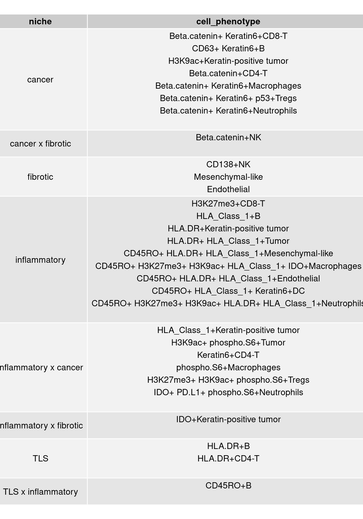

```r
tabCellPhen2 <- tabCellPhen %>%
  mutate(niche = paste(type1,type2,sep=" x "))%>%
  #full_join(.,archs.CT,by=("region"))%>%
  mutate(niche=str_replace_all(niche," x NA",""))%>%
  filter(!(cell_type %in% c("DC / Mono", "CD3-T", "Mono / Neu", "Other immune"))) %>%
  group_by(niche)%>%mutate(cells = paste(unique(cell_type),collapse='\n'))%>%
  # mutate(region=str_replace_all(region," x NA",""))%>%
  # group_by(region)%>%
  # mutate(cellPh2 = paste(unique(cell_type),collapse="\n"))%>%
  # ungroup()%>%
  # mutate(cellPh = ifelse(region %in% pull(archs.CT,region),paste(archs.CT[archs.CT$region==region,"cell_type"],collapse="\n"),"")) %>%
  group_by(niche,cell_type)%>%
  mutate(cell_phenotype= paste0(paste(marker, collapse = " "),cell_type)) %>%
  ungroup()%>%

  group_by(niche)%>%
  mutate(cell_phenotype=paste(unique(cell_phenotype),collapse="\n")) %>%
  distinct(niche, .keep_all = TRUE)%>%
  arrange(niche)%>%dplyr::select(niche, cells,cell_phenotype)



tabCellPhen3 <- tabCellPhen2%>%
  #mutate(region=str_replace_all(region," x NA",""))%>%
  mutate(cellPh =ifelse(niche %in% pull(archs.CT,niche),paste(archs.CT[archs.CT$niche==niche ,"cell_type"],collapse="\n"),""))%>%
  rowwise()%>%
  mutate(ct = ifelse(grepl("\n",cellPh,fixed=TRUE)==FALSE,paste(setdiff(as.vector(cellPh),str_split(cells,"\n")[[1]]),collapse="\n"),ifelse(grepl("\n",cells,fixed=TRUE)==FALSE,paste(setdiff(str_split(cellPh,"\n")[[1]], as.vector(cells)),collapse="\n"),paste(setdiff(str_split(cellPh,"\n")[[1]],str_split(cells,"\n")[[1]]),collapse="\n"))))%>%
  mutate(cell_phenotype = paste(cell_phenotype,ct,sep="\n"),.keep="unused")%>%
  dplyr::select(-c(cells, cellPh))%>%#mutate(sign  = "+")
  #distinct(region, .keep_all = TRUE)%>%
  arrange(niche)



#### TEST
#tabCellPhen3%>%rowwise()%>%mutate(ct = ifelse(grepl("\n",cellPh,fixed=TRUE)==FALSE,paste(setdiff(as.vector(cellPh),str_split(cells,"\n")[[1]]),collapse="\n"),ifelse(grepl("\n",cells,fixed=TRUE)==FALSE,paste(setdiff(str_split(cellPh,"\n")[[1]], as.vector(cells)),collapse="\n"),paste(setdiff(str_split(cellPh,"\n")[[1]],str_split(cells,"\n")[[1]]),collapse="\n"))))


### Display and save table in pdf
 # th1 <- ttheme_minimal(colhead=list(bg_params=list(col="black",fill = "white")),
 #                       core=list(bg_params = list(fill = 'white', col="black")))
   th1 <- ttheme_default()#colhead=list(bg_params=list(fontfamily="liberation")),
  #                      core=list(bg_params = list(fontfamily="liberation")))

 g1 <- tableGrob(tabCellPhen3,rows=NULL,theme = th1)#(tabCellPhen2%>%mutate(region=str_replace_all(region," x NA","")),rows=NULL,theme = th1)
                 #gpar.corefill = gpar(fill = "white", col = "grey95"))
 grid.newpage()
 grid.draw(g1)
```

```r
 ggsave("./figs/tab_tmens.pdf",g1,width=7,height=10)
#
 #rm(g1)
```

#### Heatmaps organized by cell types and markers

```r
cts <- unique(pull(as_tibble(cMf2,rownames=NA)%>%rownames_to_column(var="names")%>%separate(names,into=c("cell_type","marker"),sep=";"),cell_type))
markersCorr <- unique(pull(as_tibble(cMf2,rownames=NA)%>%rownames_to_column(var="names")%>%separate(names,into=c("cell_type","marker"),sep=";"),marker))

######### HEATMAP ORGANIZED BY CELL TYPES
CM_TMENs_ct <- as_tibble(cMf2,rownames=NA)%>%
     rownames_to_column(var="names")%>%
     separate(names,into=c("cell_type","marker"),sep=";")%>%#mutate(marker=paste0(marker,"+"))%>%
     pivot_longer(cols=c('a1','a2','a3',"a4","a1a2","a1a3","a1a4","a2a3","a2a4","a3a4"),names_to = "region",values_to="corr_val")%>%
   mutate(idx =match(cell_type, cts))%>%
     group_by(cell_type)%>%mutate(corr_val = corr_val+ (idx-1)*10)%>%pivot_wider(names_from="region", values_from="corr_val")%>%mutate(names = paste(cell_type,marker,sep=";"))%>%column_to_rownames(var="names")#%>%dplyr::select(-c(cell_type,idx))

dists <- dist(as.matrix(CM_TMENs_ct%>%dplyr::select(-c(cell_type,marker,idx))),method="euclidean")
hclustCells <- hclust(dists,method="ward")
```

```
## The "ward" method has been renamed to "ward.D"; note new "ward.D2"
```

```r
#plot(as.dendrogram(hclustCells))
cellTypes <- data.frame(cell_type =pull(CM_TMENs_ct ,cell_type))
Markers<- pull(CM_TMENs_ct ,marker)

rownames(cellTypes) <- rownames(CM_TMENs_ct)
#rownames(Markers) <-rownames(CM_TMENs_ct)
pdf("./figs/cM_byCells2.pdf",height=8, width=ifelse(figWidth<6, 6, figWidth+2))
pheatmap(t(cMf2),cluster_cols = hclustCells,cluster_rows = FALSE,annotation_col=cellTypes,labels_col = Markers)#
dev.off()
```

```r
####### HEATMAP ORGANIZED BY MARKERS
CM_TMENs_ph <- as_tibble(cMf2,rownames=NA)%>%
     rownames_to_column(var="names")%>%
     separate(names,into=c("cell_type","marker"),sep=";")%>%#mutate(marker=paste0(marker,"+"))%>%
     pivot_longer(cols=c('a1','a2','a3',"a4","a1a2","a1a3","a1a4","a2a3","a2a4","a3a4"),names_to = "region",values_to="corr_val")%>%
   mutate(idx =match(marker, markersCorr))%>%arrange(marker)%>%
     group_by(marker)%>%mutate(corr_val = corr_val+ (idx-1)*10)%>%pivot_wider(names_from="region", values_from="corr_val")%>%mutate(names = paste(marker,cell_type,sep=";"))%>%column_to_rownames(var="names")#%>%dplyr::select(-c(marker,idx))

Markers2 <- data.frame(marker= pull(CM_TMENs_ph,marker))
rownames(Markers2) <- rownames(CM_TMENs_ph)
cellTypes2 <- pull(CM_TMENs_ph,cell_type)

dists2 <- dist(as.matrix(CM_TMENs_ph%>%dplyr::select(-c(marker,cell_type,idx))),method="euclidean")
hclustPhen <- hclust(dists2,method="ward")
```

```
## The "ward" method has been renamed to "ward.D"; note new "ward.D2"
```

```r
#plot(as.dendrogram(hclustPhen))

cMf.copy <- cMf2
rownames(cMf.copy)<- unname(unlist(sapply(rownames(cMf.copy),function(x){paste0(strsplit(x,";")[[1]][2],";",strsplit(x,";")[[1]][1])})))#sub('(\\w|\\.|\\_|\\ / |+);(\\w|.|_| / |+)', '\\2;\\1', rownames(cMf))#sub('([^;]);([^;])', '\\2;\\1^', rownames(cMf))
#
cMf_ordered <- cMf.copy%>%as_tibble(rownames=NA)%>%rownames_to_column(var="names")%>%separate(col="names",into=c("marker","cell_type"),sep=";")%>%group_by(marker)%>%arrange(marker)%>%mutate(names=paste0(marker,";",cell_type))%>%column_to_rownames(var="names")%>%dplyr::select(-c(cell_type,marker))

pdf("./figs/cM_byMarkers2.pdf",height=8, width=ifelse(figWidth<6, 6, figWidth+2))
pheatmap(as.matrix(cMf_ordered%>%t),cluster_cols = hclustPhen,cluster_rows = FALSE,annotation_col = Markers2,labels_col = cellTypes2)
dev.off()
```

```r
rm(cMf.copy)
rm(CM_TMENs_ph)
rm(CM_TMENs_ct)
#pheatmap(t(as.matrix(CM_TMENs_ct)),cluster_cols = TRUE,cluster_rows = FALSE)
```

#### Niche-phentoype mapping per cell type

```r
library(RColorBrewer)
library(pheatmap)

## Get cell types that are associated with a tmen/interface
cts <- unique(pull(as_tibble(cMf2,rownames=NA)%>%rownames_to_column(var="names")%>%separate(names,into=c("cell_type","marker"),sep=";"),cell_type))
markersCorr <- unique(pull(as_tibble(cMf2,rownames=NA)%>%rownames_to_column(var="names")%>%separate(names,into=c("cell_type","marker"),sep=";"),marker))


### Classify correlations by cell type
# CM_TMENs_ct <- as_tibble(cMf,rownames=NA)%>%
#      rownames_to_column(var="names")%>%
#      separate(names,into=c("cell_type","marker"),sep=";")%>%
#      mutate(marker=paste0(marker,"+"))%>%pivot_longer(cols=c('a1','a2','a3',"a4","a1a2","a1a3","a1a4","a2a3","a2a4","a3a4"),names_to = "region",values_to="corr_val")%>%
#    mutate(idx =match(cell_type, cts))%>%
#      group_by(cell_type)%>%mutate(corr_val = corr_val+ (idx-1)*10)%>%pivot_wider(names_from="region", values_from="corr_val")%>%mutate(names = paste(cell_type,marker,sep=";"),.keep="unused")%>%column_to_rownames(var="names")%>%dplyr::select(-c(cell_type,idx))
#
# pdf("./figs/tweakedCM_corr.pdf",height=8, width=ifelse(figWidth<6, 6, figWidth+2));pheatmap(t(as.matrix(CM_TMENs_ct)),cluster_cols = TRUE,cluster_rows = FALSE);dev.off()


#### NEW VERSION
# We proceed cell type wise and do hierarchical clustering of the markers to group the phenotypes together
# 1 plot for 1 cell type
# same color bar
# export heatmaps into pdf with same cell size of the matrix
# group them manually in Inkscape
corrCM <- readRDS("./corMatrix_raw.rds")
corrCM <-corrCM[rowSums(is.na(corrCM))==0,]
breaksCols <- seq(min(corrCM),max(corrCM),by=.1) # cMf
ct_df <-group_split(as_tibble(corrCM,rownames=NA)%>%rownames_to_column(var="names")%>%separate(names,into=c("cell_type","marker"),sep=";")%>%group_by(cell_type))

list_heatmapsCT <- lapply(ct_df,FUN = function(x){
  ct <- str_replace(unique(x$cell_type),"/","_" )#strsplit(rownames(x)["cell_type"],';')[[1]][1]
  print(ct)
  #p <- pheatmap(as.matrix(x%>%mutate(names= paste(cell_type,marker),.keep="unused")%>%column_to_rownames(var="names")),cluster_rows = TRUE,cluster_cols = FALSE)
  #print(ct)
  # pheatmap(as.matrix(x%>%mutate(names= paste(cell_type,marker),.keep="unused")%>%column_to_rownames(var="names")%>%t()),
  #                                                    color = colorRampPalette(rev(brewer.pal(n = 7,name = "RdYlBu")))( length(breaksCols)), cluster_rows = TRUE,
  #                                                    cluster_cols = FALSE,
  #                                                    cell_width=1,cell_height = 2)
  #pdf(paste0("./figs/",ct,".pdf"));
  colnames(x) <- str_replace_all(colnames(x), c("a2a3"="inflammxcancer",
                                                           "a1a3" = "TLSxcancer",
                                                           "a1a2"= "TLSxinflamm",
                                                           "a1a4" = "TLSxfibrotic",
                                                           "a2a4" ="inflammxfibrotic",
                                                           "a3a4" = "cancerxfibrotic"))
  colnames(x) <- str_replace_all(colnames(x),c("a1" = "TLS","a2" = "inflamm","a3" = "cancer","a4" = "fibrotic"))
  pdf(paste0("./figs/",ct,".pdf"));
  pheatmap(as.matrix(x%>%arrange(marker)%>%column_to_rownames(var="marker")%>%dplyr::select(-(cell_type))),#x%>%mutate(names= paste(cell_type,marker),.keep="unused")%>%column_to_rownames(var="names")),#%>%t()),
                                                     color = colorRampPalette(rev(brewer.pal(n = 7,name = "RdYlBu")))( length(breaksCols)), cluster_cols = TRUE,
                                                     cluster_rows = FALSE,main=ct,
                                                     cell_width=1,cell_height = 2);
  dev.off()

})
```

```
## [1] "B"
```

```
## [1] "CD3-T"
```

```
## [1] "CD4-T"
```

```
## [1] "CD8-T"
```

```
## [1] "DC"
```

```
## [1] "DC _ Mono"
```

```
## [1] "Endothelial"
```

```
## [1] "Keratin-positive tumor"
```

```
## [1] "Macrophages"
```

```
## [1] "Mesenchymal-like"
```

```
## [1] "Mono _ Neu"
```

```
## [1] "Neutrophils"
```

```
## [1] "NK"
```

```
## [1] "Other immune"
```

```
## [1] "Tregs"
```

```
## [1] "Tumor"
```

```r
#%>%filter(marker!="H3K9ac_H3K27me3")

# i=0
# for (p in list_heatmapsCT){
#   i<- i+1
#   pdf(paste0("./figs/",strsplit(rownames(x)[1],';')[[1]][1],".pdf"),width=4);p;dev.off()
# }


# map(ct_df,.f = function(x) pheatmap(as.matrix(x%>%mutate(names= paste(cell_type,marker),.keep="unused")%>%column_to_rownames(var="names")),cluster_rows = TRUE,cluster_cols = FALSE))
# #pheatmap(as.matrix(ct_df%>%mutate(names= paste(cell_type,marker),.keep="unused")%>%column_to_rownames(var="names")),cluster_rows = TRUE,cluster_cols = FALSE)
#
# pheatmap(as.matrix(ct_df%>%mutate(names= paste(cell_type,marker),.keep="unused")%>%column_to_rownames(var="names")))
# rm(list_heatmapsCT)
# pdf("./figs/corMatrix_ct.pdf",height=8,width=ifelse(figWidth<6, 6, figWidth+2)); pheatmap(t(as.matrix(cMf)),annotation_col =data.frame (cell_type =factor(pull(as_tibble(cMf,rownames=NA)%>%rownames_to_column(var="names")%>%separate(names,into=c("cell_type","marker"),sep=";"),cell_type), levels = cts,labels = CELLTYPES) )); dev.off()





##### CELL TYPE  hclust
# annot =data.frame(cell_type =factor(pull(as_tibble(cMf,rownames=NA)%>%rownames_to_column(var="names")%>%separate(names,into=c("cell_type","marker"),sep=";"),cell_type), levels = cts,labels = CELLTYPES),marker = factor(pull(as_tibble(cMf,rownames=NA)%>%rownames_to_column(var="names")%>%separate(names,into=c("cell_type","marker"),sep=";"),marker),levels = markersCorr,labels = markersCorr))
#
# rownames(annot) <- colnames(t(cMf))
# pheatmap(t(as.matrix(cMf)),annotation_col =annot,cluster_cols = FALSE,cluster_rows=FALSE,show_colnames = FALSE)
```

#### PCA on correlation matrix of cell markers VS TMENs

Can we find cross-cells phenotypes that are associated to niches ? Are they associated to core niches or do they arise at the interface ? If so, is it a continuum or do we have clusters ?

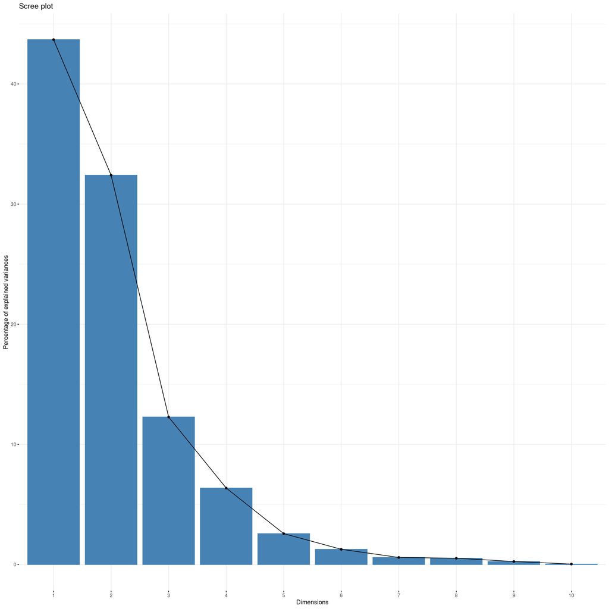

```r
###PCA on correlation matrix
library(pheatmap)
library(RColorBrewer)
library(ggplot2)
CM_TMENs.pca <- dudi.pca(cMf2[,c('a1','a2','a3',"a4","a1a2","a1a3","a1a4","a2a3","a2a4","a3a4")],center=FALSE, scale=TRUE,scannf=FALSE,nf=3)
fviz_eig(CM_TMENs.pca)
```

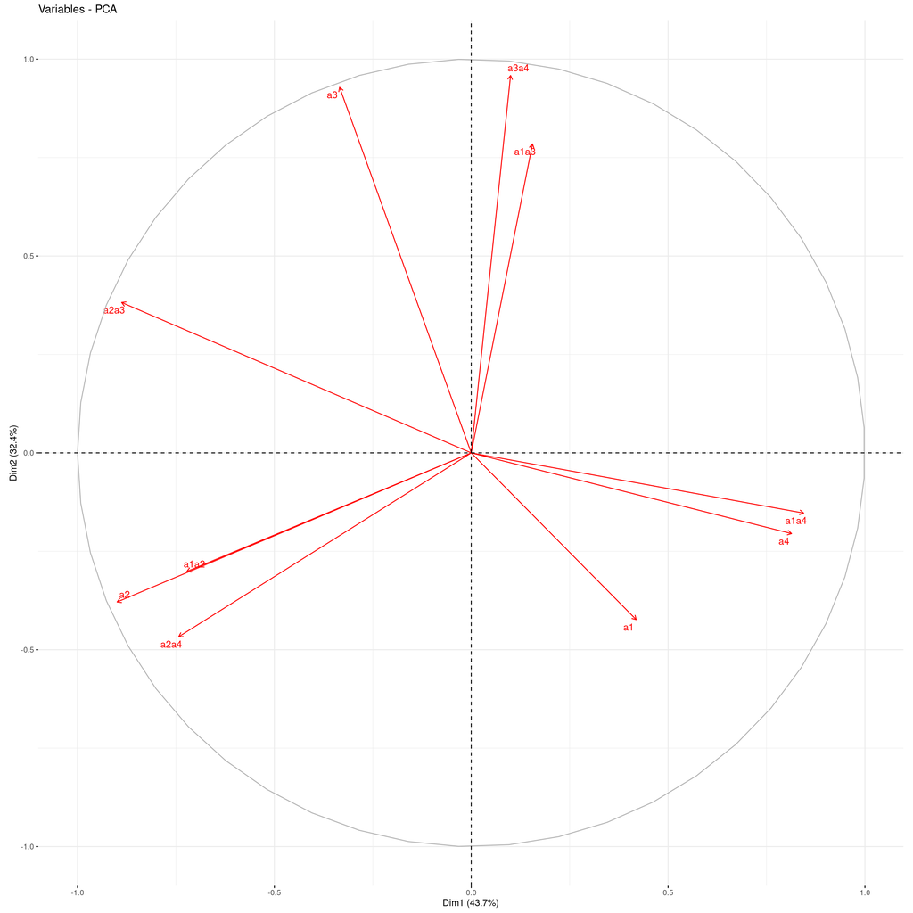

```r
fviz_pca_var(CM_TMENs.pca,col.var = "red",repel=TRUE)
```

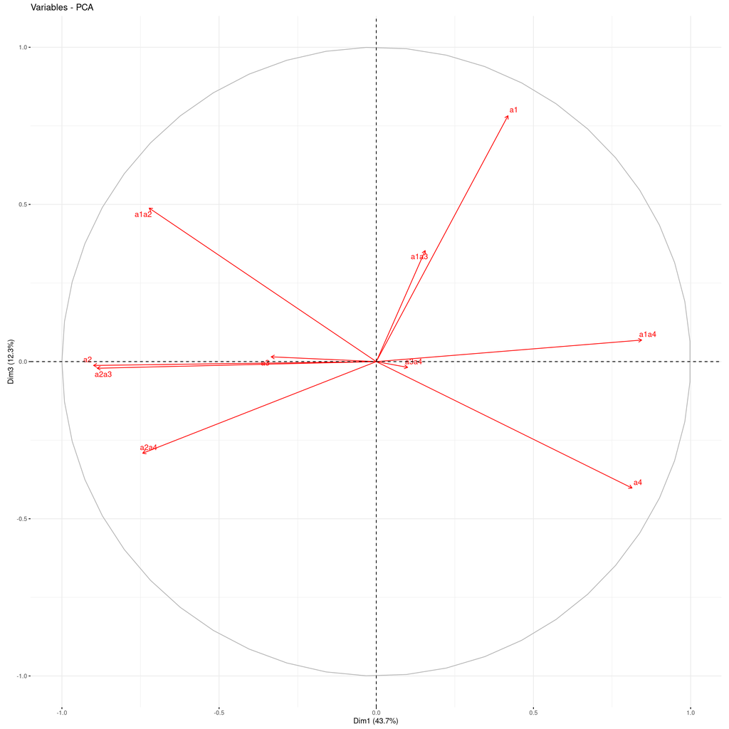

```r
fviz_pca_var(CM_TMENs.pca,axes=c(1,3),col.var = "red",repel=TRUE)
```

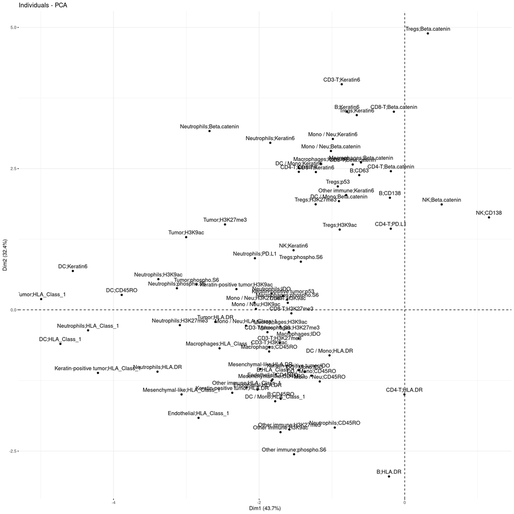

```r
fviz_pca_ind(CM_TMENs.pca)
```

```r
CM <- cMf2%>%as_tibble(rownames=NA)%>%rownames_to_column(var="names")%>%separate(col=names, into=c("cell_type","marker"),sep=";")%>%dplyr::select(c(cell_type,marker))

# CM_TMENs.pca$co[,1:3] <- sweep(CM_TMENs.pca$co[,1:3], 2, CM_TMENs.pca$eig[1:3]^0.8, FUN='/')
# CM_TMENs.pca$li[,1:3] <- sweep(CM_TMENs.pca$li[,1:3], 2, CM_TMENs.pca$eig[1:3], FUN='/')

colorCount = length(unique(CM$marker))
getPalette = colorRampPalette(brewer.pal(9, "Set1"))


# plot1 <- ggplot(data = cbind(CM_TMENs.pca$li[,1:2],CM), aes(x = Axis1, y = Axis2,color=marker,shape= cell_type,size=3)) +
#       geom_point()+scale_color_manual(values=getPalette(colorCount))+
#   scale_shape_manual(values=c(0,1,2,3,4,5,6,7,8,9,10,12,13,16,17,18))+#c(0:length(unique(CM$cell_type))-1)
#           xlab("PC 1") + ylab("PC 2")
#
# plot1

# plot2 <- ggplot(data = cbind(CM_TMENs.pca$li[,1:3],CM), aes(x = Axis1, y = Axis3,color=marker,shape= cell_type,size=3)) +
#       geom_point()+scale_color_manual(values=getPalette(colorCount))+
#   scale_shape_manual(values=c(0,1,2,3,4,5,6,7,8,9,10,12,13,16,17,18))+#c(0:length(unique(CM$cell_type))-1)
#           xlab("PC 1") + ylab("PC 3")
#
#
# plot2
#
#
fig1 <- plot_ly(x = CM_TMENs.pca$li[,1],
           y = CM_TMENs.pca$li[,2],
           z = CM_TMENs.pca$li[,3],
           type="scatter3d",
           #color = ~markerCells,
           alpha = 0.5,
           mode="markers",
           name= "cells",
           marker = list(size= 5),
           showlegend=TRUE)%>%
    layout(scene = list(xaxis = list(title = "PC1"),
                                       yaxis = list(title = "PC2"),
                                       zaxis = list(title = "PC3") ))
#fig1
```

The third Principal Component explains 12 % of the total variance. TLS-cancer as well as TLS niche positively associates with the PC3.

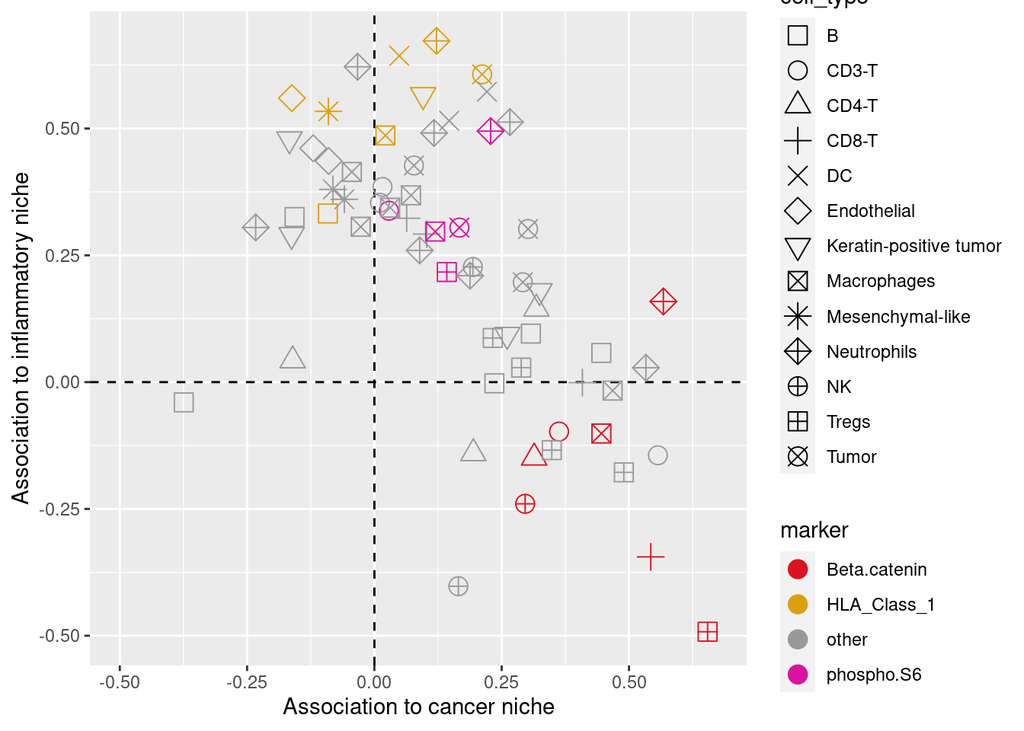

```r
corr_cm <-as_tibble(cMf2,rownames=NA)%>%rownames_to_column(var="names")%>%separate(col=names, into=c("cell_type","marker"),sep=";")%>%filter(!(cell_type %in% c("DC / Mono", "Mono / Neu","Other immune")))%>%mutate(marker=ifelse(marker%in%c("phospho.S6","Beta.catenin","HLA_Class_1"),marker,"other"))#%>%group_by(marker)%>%mutate(randA2 = ifelse(marker=="other",rnorm(),))
library(RColorBrewer)
#library(tune)
colorCount = length(unique(corr_cm$marker))
#getPalette = colorRampPalette(brewer.pal(9, "Set1"))#Dark2

ggplot(corr_cm, aes(x=a3,y=a2,color=marker,shape=cell_type))+
  geom_hline(yintercept=0, color="black",linetype= "dashed") + geom_vline(xintercept=0,color="black",linetype="dashed")+
  geom_point(size = 4)+#scale_color_brewer(palette="Set1")+#scale_color_manual(values=getPalette(colorCount))+
  scale_shape_manual(values=c(0,1,2,3,4,5,6,7,8,9,10,12,13,16,17,18))+# scale_shape_manual(values = c(0,3,18,7))++# 7,3,5
  scale_color_manual(values=c("#DB121F","#DBA012","#999999","#DB129F"))+
  ylab("Association to inflammatory niche")+xlab("Association to cancer niche")+

  xlim(-0.5,max(cbind(corr_cm$a2,corr_cm$a3))) + ylim(-0.5,max(cbind(corr_cm$a2,corr_cm$a3)))
```

```r
ggsave("./figs/corrCancerInfl.pdf",width=6,height=4)
```

#### Sum of Squares of correlations per TMENs (core and interfaces)

```r
#install.packages("ggrepel")
library(ggrepel)
coreCorr <- cMf2[,c('a1','a2','a3',"a4")]
interCorr <- cMf2[,c("a1a2","a1a3","a1a4","a2a3","a2a4","a3a4")]
SS <- apply(cMf2[,c('a1','a2','a3',"a4","a1a2","a1a3","a1a4","a2a3","a2a4","a3a4")],2, function(x) sum(x)^2)#var(x) #sum(x-mean(x))^2
sort(SS)
```

```
##         a1a3         a3a4           a1         a1a2         a1a4           a3
##   0.06433508   8.32897787  24.73537633  47.25262499  82.99101902 121.71852810
##         a2a4           a2           a4         a2a3
## 157.81262070 365.93024909 403.16236511 529.33823065
```

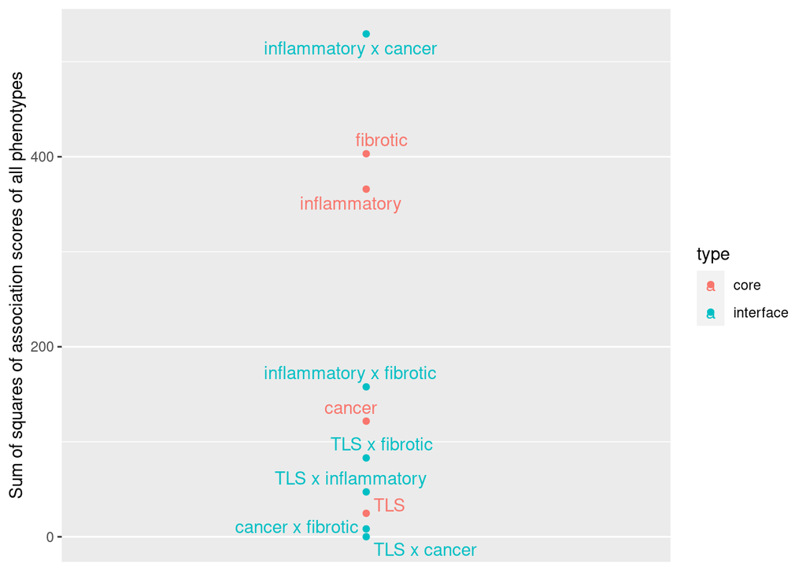

```r
names(SS) <- str_replace_all(names(SS), c("a2a3"="inflammatory x cancer",
                                                           "a1a3" = "TLS x cancer",
                                                           "a1a2"= "TLS x inflammatory",
                                                           "a1a4" = "TLS x fibrotic",
                                                           "a2a4" ="inflammatory x fibrotic",
                                                           "a3a4" = "cancer x fibrotic"))
names(SS) <- str_replace_all(names(SS),c("a1" = "TLS","a2" = "inflammatory","a3" = "cancer","a4" = "fibrotic"))

x <- rep(0,length(SS))
tmens_SS <- as_tibble(cbind(SS,x),rownames=NA)%>%rownames_to_column(var="tmen")%>%mutate(type = ifelse(tmen %in% c("TLS","inflammatory","cancer","fibrotic"),"core","interface"))
p <- ggplot(tmens_SS , aes(x, SS,color=type,label=tmen)) + geom_point()+ylab("Sum of squares of association scores of all phenotypes")+geom_text_repel()
p + theme(axis.line.x=element_blank(),
          axis.text.x=element_blank(),
          axis.ticks.x=element_blank(),
          axis.title.x=element_blank(),
          panel.grid.minor.x=element_blank(),
          panel.grid.major.x=element_blank())
```

```r
ggsave("./figs/SS_tmens.pdf",height=4,width=3)
```

- The interface between cancer and inflammatory niches is highly correlated with specific phenotypes. It associates the most phenotypes with environment.
- Many cell phenotypes highly associate with the fibrotic niche (mostly anti-correlations): most cells anti-correlate with this niche because it has a low cell density. We also lack stromal markers and ECM markers as well as some cytokines.
- The cancer niche has an average SS, it correlates with cell phenotypes observed such as beta catenin, phospho S6 and keratin.
- The inflammatory niche is the third environment whose SS is high meaning that it highly correlates with cell phenotypes that are likely to be pro-inflammatory
- Cell phenotypes poorly correlate with a TLS-cancer niches interface. This suggests that either there is no phenotype that is specific to this environment or simply that we find almost no cells at this interface or that the panel of markers doesn’t cover proteins that might be in this region.
- In general, interfaces with TLS have a poor SS value. It reveals that there are few phenotypes that highly associate with those specific immune contextures, or that phenotypes poorly associate with them.

In conclusion, cancer-inflammation interface is the interface that associates best phenotypes with space. In other words, this is the context for generation of environment-dependent cell phenotypes such as antigen presentation or immunosuppression. Previous work reveal that the latter enhances tumor growth and immune escape

```r
#############################-------------------TO CLEAN-------------------#############################
## look for interface markers

coreIdx <- which(colnames(corCMtmens.qval) %in% c("a1", "a2", "a3", "a4"))
intfIdx <- setdiff(1:ncol(corCMtmens.qval), coreIdx)
# corIntfCoretmens <-cMf%>%as_tibble(rownames=NA)%>%
#   rownames_to_column(var="names")%>%
#   pivot_longer(cols = c("a1", "a2", "a3", "a4"),names_to = "coreTMEN",values_to = "coreVal")%>%
#   pivot_longer(cols = c("a1a2","a1a3","a1a4","a2a3","a2a4",
#                   "a3a4","a1a2a3","a1a2a4","a1a3a4","a2a3a4","a1a2a3a4"),names_to = "intfTMEN",values_to = "intfVal")%>%
#   group_by(names,coreTMEN,intfTMEN)%>%mutate(interface = ifelse((abs(coreVal)<abs(intfVal))&(grepl(coreTMEN,intfTMEN,fixed=TRUE)),TRUE,FALSE))%>%filter(interface==TRUE)%>%filter(grepl("Unidentified",names,fixed=TRUE)==FALSE)
#
# corIntfCoretmens2 <- corIntfCoretmens%>%ungroup()%>%group_by(names,intfTMEN)%>%distinct(intfTMEN,.keep_all=TRUE)%>%dplyr::select(c(names,intfTMEN,intfVal))%>%pivot_wider(id_cols = c("names","intfTMEN"),names_from="intfTMEN",values_from="intfVal")%>%column_to_rownames((var="names"))
# pdf("./corIntfTMENs.pdf",height=8,width=15)
# pheatmap(as.matrix(corIntfCoretmens2),cluster_rows=FALSE, cluster_cols=FALSE)
# dev.off()
#
# corsInterf <- cMf[names(which(apply(cMf[,coreIdx]<cMf[,intfIdx],1,sum)>0)),]

# coreIdx <- which(colnames(corCMtmens.qval) %in% c("a1", "a2", "a3", "a4"))
# intfIdx <- setdiff(1:ncol(corCMtmens.qval), coreIdx)
# intfOnlyIdx <- (apply(corCMtmens.qval[,coreIdx] < qThreshold, 1, sum) == 0 & apply(corCMtmens.qval[,intfIdx] < qThreshold*5, 1, sum) > 0)
#intfOnlyIdx =
#which(intfOnlyIdx)

#intfOnlyIdx = (apply(corMatrix[,coreIdx] < qThreshold, 1, sum) == 0 & apply(corCMtmens.qval[,intfIdx] < qThreshold, 1, sum) > 0)
#### FIlter only the duo cell type,marker that has significantly non-null correlations with interface of TMENs
# cMf <- corMatrix[names(which(intfOnlyIdx)),]
# figWidth<-nrow(cMf) * 30/267
# pdf("cMf_intf.pdf", height=6, width=ifelse(figWidth<6, 6, figWidth)); pheatmap(cMf %>% t); dev.off()
# pheatmap(cMf)

#matrix(1:12, 3, 4) %>% as.numeric() %>% matrix(3, 4)

pheatmap(t(as.matrix(corCMtmens%>%column_to_rownames(var="names"))),display_numbers= t(round(as.matrix(corCMtmens.pval%>%column_to_rownames(var="names")),3)))

## Significant correlations with  1 TMEN
corCM_1TMEN.pval <- corCMtmens.pval%>%dplyr::select(names,a1,a2,a3,a4)%>%filter(a1<=0.05 |a2<=0.05|a3<=0.05|a4<=0.05)
corCM_1TMEN <- merge(corCMtmens%>%dplyr::select(names,a1,a2,a3,a4),corCM_1TMEN.pval,by=c("names"))#%>%filter(a1<=0.05 |a2<=0.05|a3<=0.05|a4<=0.05)

pheatmap(t(as.matrix(corCM_1TMEN%>%column_to_rownames(var="names")%>%dplyr::select(c(a1.x,a2.x,a3.x,a4.x)))),
         display_numbers =t(round(as.matrix(corCM_1TMEN.pval%>%column_to_rownames(var="names")),3)))

### Significant correlations with interfaces of TMENs
corCM_inter_2TMENs.pval <- corCMtmens.pval%>%
  dplyr::select(names,a1a2,a1a3,a1a4,a2a3,a2a4,a3a4)%>%
  filter(a1a2<=0.05 | a1a3<=0.05 | a1a4<=0.05 | a2a3<=0.05 | a2a4<=0.05 | a3a4<=0.05)

corCM_inter_2TMENs <- merge(corCMtmens%>%dplyr::select(names,a1a2,a1a3,a1a4,a2a3,a2a4,a3a4),
                            corCM_inter_2TMENs.pval,
                            by = c("names"))
pheatmap(t(as.matrix(corCM_inter_2TMENs%>%column_to_rownames(var = "names")%>%dplyr::select(c(a1a2.x,a1a3.x,a1a4.x,a2a3.x,a2a4.x,a3a4.x)))),
         display_numbers = t(round(as.matrix(corCM_inter_2TMENs.pval%>%column_to_rownames(var = "names")),3)))


corCM_inter3TMENs.pval  <- corCMtmens.pval%>%dplyr::select(names,a1a2a3,a1a2a4,a1a3a4,a2a3a4)%>%filter(a1a2a3<=0.05 |a1a2a4<=0.05 | a1a3a4<=0.05 | a2a3a4<=0.05)
corCM_inter3TMENs <- merge(corCMtmens%>%dplyr::select(names,a1a2a3,a1a2a4,a1a3a4,a2a3a4),corCM_inter3TMENs.pval,by="names")

# heatmap(as.matrix(corCM_1TMEN), Rowv=NA,Colv = NA,scale="none",
#         labRow = corMatrix%>%as_tibble(rownames=NA)%>%rownames_to_column(var="names")%>%pull(names))
#res <-as_tibble(corMatrix,rownames=NA)%>%filter(a1a2>=0.05)

## Significant correlations with interfaces of 3 TMENs
corCM_TMENS_signif <- corMatrix%>%as_tibble(rownames=NA)%>%
  rownames_to_column(var="names")%>%
  separate(names,into=c("cell_type","marker"),sep=";")%>%
  drop_na()%>%filter(a1<=0.05 |a2<=0.05|a3<=0.05|a4<=0.05|a1a2<=0.05 |a1a3<=0.05|a1a4<=0.05|a2a3<=0.05|a2a4<=0.05|a3a4<=0.05| a1a2a3<=0.05 |a1a2a4<=0.05|a1a3a4<=0.05|a2a3a4<=0.05)

cts <- unique(corCM_TMENS_signif%>%pull(cell_type))
combCT <- corMatrix%>%as_tibble(rownames=NA)%>%rownames_to_column(var="names")%>%pull(names)
# h1 <- list()
#
# redgreen <- c("green","red" )
# pal <- colorRampPalette(redgreen)(100)

# library(lattice)
#
# h1 <- lapply(X=cts,function(c){
#   markersCT <- combCT[str_detect(combCT,paste0(c,";"))]
#   matrixToPlot <- as.matrix(corCM_TMENS_signif)
#   rownames(matrixToPlot) <-combCT
#   matrixToPlot2 <- as_tibble(matrixToPlot,rownames=NA)%>%filter(cell_type==c)%>%dplyr::select(c(a1,a2,a3,a4,a1a2,a1a3,a1a4,a2a3,a2a4,a3a4,a1a2a3,a1a2a4,a1a3a4,a2a3a4))
#   fig <-levelplot(matrixToPlot,xlab = paste0("markers for cell type  ",c),ylab = c("TLS","infl.","cancer","fibr","TLS-infl","TLS-cancer","TLS-fibr","infl-cancer","infl-fibr","cancer-fibr","TLS-infl-canc","TLS-infl-fibr","TLS-cancer-fibr","infl-cancer-fibr"))#heatmap(matrixToPlot,Rowv = NA,Colv=NA, scale="none",
#                 #labRow  = combCT,col=pal)
#   print(fig)
# })
# for (c in range(cts)){
# fig <- heatmap(as.matrix(corCM_TMENS_signif%>%dplyr::select(c(a1,a2,a3,a4,a1a2,a1a3,a1a4,a2a3,a2a4,a3a4,a1a2a3,a1a2a4,a1a3a4,a2a3a4)),Rowv = NA,Colv=NA, scale="none",
#    labROw  = combCT))
# append(h1,fig)
# }
```

```r
plot_3D_ternary_cell_markers("Keratin-positive tumor", "Ki67")
plot_3D_ternary_cell_markers("Tumor", "Ki67")
plot_3D_ternary_cell_markers("Keratin-positive tumor","PD.L1")
```

```r
#### CD4-T
CellTypes.toPlot <- unique(selectedMarkers[["cell_type"]])
library('IRdisplay')

Markers.toPlot <-selectedMarkers%>%filter(cell_type == "CD4-T")%>%pull(marker)
PlotsList <- list()
PlotsList <- lapply(Markers.toPlot, function(marker1){
  fig <- plot_3D_ternary_cell_markers("CD4-T", marker1)
  print(htmltools::tagList(fig))
  #cat(as.character(htmltools::tagList(fig)))#,browse=TRUE
  #htmlwidgets::saveWidget(fig,"fig1.html")
  #htmltools::html_print(fig)
})
```

```r
#### CD8-T
CellTypes.toPlot <- unique(selectedMarkers[["cell_type"]])

  Markers.toPlot <-selectedMarkers%>%filter(cell_type == "CD8-T")%>%pull(marker)
PlotsList <- list()
PlotsList <- lapply(Markers.toPlot, function(marker1){
  fig <- plot_3D_ternary_cell_markers("CD8-T", marker1)
  #cat(as.character(htmltools::tagList(fig)))#
  print(htmltools::tagList(fig))
})

#plot_3D_ternary_cell_markers("CD8-T", Markers.toPlot[1])

plot_3D_ternary_cell_markers("CD8-T","PD1")
```

### Dendritic cells

```r
#### DC
#CellTypes.toPlot <- unique(selectedMarkers[["cell_type"]])

Markers.toPlot <-selectedMarkers%>%filter(cell_type == "DC")%>%pull(marker)
PlotsList <- list()
PlotsList <- lapply(Markers.toPlot, function(marker1){
  fig <- plot_3D_ternary_cell_markers("DC", marker1)
  print(htmltools::tagList(fig))
})

#plot_3D_ternary_cell_markers("DC", Markers.toPlot[1])
```

```r
#### Tregs
#CellTypes.toPlot <- unique(selectedMarkers[["cell_type"]])

  Markers.toPlot <-selectedMarkers%>%filter(cell_type == "Tregs")%>%pull(marker)
PlotsList <- list()
PlotsList <- lapply(Markers.toPlot, function(marker1){
  fig <- plot_3D_ternary_cell_markers("Tregs", marker1)
  print(htmltools::tagList(fig))
})
```

### Macrophages

```r
#### Macrophages
#CellTypes.toPlot <- unique(selectedMarkers[["cell_type"]])

  Markers.toPlot <-selectedMarkers%>%filter(cell_type == "Macrophages")%>%pull(marker)
PlotsList <- list()
PlotsList <- lapply(Markers.toPlot, function(marker1){
  fig <- plot_3D_ternary_cell_markers("Macrophages", marker1)
  print(htmltools::tagList(fig))
})
```

### NK cells

```r
#### NK
#CellTypes.toPlot <- unique(selectedMarkers[["cell_type"]])

  Markers.toPlot <-selectedMarkers%>%filter(cell_type == "NK")%>%pull(marker)
PlotsList <- list()
PlotsList <- lapply(Markers.toPlot, function(marker1){
  fig <- plot_3D_ternary_cell_markers("NK", marker1)
  print(htmltools::tagList(fig))
})

#plot_3D_ternary_cell_markers("NK", Markers.toPlot[1])
```

### Neutrophils

```r
#### Neutrophils
#CellTypes.toPlot <- unique(selectedMarkers[["cell_type"]])

Markers.toPlot <-selectedMarkers%>%filter(cell_type == "Neutrophils")%>%pull(marker)
PlotsList <- list()
PlotsList <- lapply(Markers.toPlot, function(marker1){
  fig <- plot_3D_ternary_cell_markers("Neutrophils", marker1)
  print(htmltools::tagList(fig))
})
#plot_3D_ternary_cell_markers("Neutrophils", "CD16")
# plot_3D_ternary_cell_markers("Neutrophils", Markers.toPlot[1])
# plot_3D_ternary_cell_markers("Neutrophils", Markers.toPlot[2])
```

### Endothelial cells

```r
#### Endothelial
#CellTypes.toPlot <- unique(selectedMarkers[["cell_type"]])

  Markers.toPlot <-selectedMarkers%>%filter(cell_type == "Endothelial")%>%pull(marker)
PlotsList <- list()
PlotsList <- lapply(Markers.toPlot, function(marker1){
  fig <- plot_3D_ternary_cell_markers("Endothelial", marker1)
  print(htmltools::tagList(fig))
})

#plot_3D_ternary_cell_markers("Endothelial", Markers.toPlot[1])
```

### Other cells

```r
plot_3D_ternary_cell_markers("B","CD20")
plot_3D_ternary_cell_markers("Keratin-positive tumor","EGFR")
#plot_3D_ternary_cell_markers("Tumor","EGFR")
```

## Non-linear relationship between markers and TMENs ?

## Methods

**Defining the environment of the cells.**

In order to understand how environment associates with cell phenotypes, we described the environment surrounding the cells using TMENs. Therefore, each cell will be computed the proportions of TMENs. We generated sites centered on cells from MIBI data. Thus, there are as many sites as cells. We computed the cell abundance across sites. We defined the proportions $\alpha$ of TMENs of a cell as is: $\rho = B \alpha$, where $\rho$ is the cell abundance in a site centered on the cell and B is the matrix of cellular profile for each TMENs. To find $\alpha$, we solved the equation with quadratic programming using *qpsolvers* library in Python. Cells labeled as “Unidentified” by Keren 2018 were discarded from the analysis.

**Correlations between cell phenotypes and environment.**

Having the cells and their environment ($\alpha$ for each cell), we collected the expression of protein markers cell type-wise. We selected only markers that were classified as “functional” according to [this paper](https://doi.org/10.1038/s42003-021-02361-1) (Patwa et al., Nature 2021). Cell phenotypes were defined as the expression of a marker in a cell type. We computed Spearman correlations between cell phenotypes and TMENs. We included the interfaces between TMENs as the product of different combinations of TMENs: TLS x cancer, cancer x fibrotic, cancer x inflammation, TLS x fibrotic, TLS x inflammatory, fibrotic x inflammatory, TLS x inflammatory x fibrotic, TLS x cancer x fibrotic, inflammatory x fibrotic x cancer, TLS x inflammatory x cancer, TLS x inflammatory x fibrotic x cancer. Spearman correlation test was performed with a False Discovery Rate correction of p values. We selected only significant q values ($\alpha = 0.01$) and the cell phenotypes whose correlation coefficient was higher than $|0.3|$ for at least one of the environments (core TMENs and interfaces). High range interfaces between TMENs ($> 2$) were excluded as they were less informative than 2-range interfaces. In total, we kept 82 correlations between cell phenotypes and 10 core and interfaces of TMENs. The analysis was conducted in R.